# Applied Modelling in Drug Development

ROeS 2025, Graz

Sebastian Weber

Novartis Pharma AG

Lukas Widmer

September 14, 2025

# Preface

## Disclaimer

The opinions & statements expressed in this presentation and on the following slides are solely of the presenters, and not necessarily those of Novartis.

## Learning Goals

After this course, you should:

- Be familiar with `brms` syntax and workflow
- Recognize its versatility for statistical modelling in drug development
- Have hands-on experience with the package from two guided exercises

and of course:

- Feel empowered to use `brms` going forward!

## Housekeeping

- Q&A: you may raise your hand at any time, or hold for Q&A sessions at the end of each section
- Laptop charging: we recommend conserving battery by keeping your laptop powered down except during the hands-on exercises
- Online case study library: https://opensource.nibr.com/bamdd
- Course materials will also be uploaded to: https://github.com/Novartis/bamdd/tree/main/workshops/graz2025

## Acknowledgements

- Paul Buerkner (Technical University of Dortmund)
- Andrew Bean (Novartis)
- Björn Holzhauer (Novartis)
- David Ohlssen (Novartis)
- Cong Zhang (Novartis)

# A `brms` modelling workflow

## Bayesian inference

$$p(\theta|y) = \frac{p(y|\theta) \, p(\theta)}{p(y)}$$

- Prior $p(\theta)$
- Model likelihood $p(y|\theta)$
- Marginal data likelihood $p(y) = \int p(y|\theta) \, p(\theta) \, d\theta$
- Posterior $p(\theta|y)$ is **conditional** on data $y$

## Bayesian inference is integration

$$\hat{\theta} = E[\theta|y] = \int \theta \, p(\theta|y) \, d\theta$$

In practice solved by Markov-Chain Monte-Carlo (MCMC) in generating *draws* $s=1, \ldots, S$

$$\theta_s \sim p(\theta|y)$$

$$\int \theta \, p(\theta|y) \, d\theta \approx \frac{1}{S} \sum_{s=1}^S \theta_s$$

## Stan project: Bayesian modelling platform

- [mc-stan.org](https://mc-stan.org/)
- [discourse.mc-stan.org](https://discourse.mc-stan.org/)
- Models are written in the Stan probabilistic programming language for priors & model likelihood conditional on data
- Hamiltonian Monte-Carlo No-U-turn sampler (NUTS)

[figure not shown]

```stan
data {
  int<lower=0> N;
  array[N] int<lower=0,upper=1> y;
}
parameters {
  real<lower=0,upper=1> theta;
}
model {
  theta ~ beta(1,1);
  y ~ bernoulli(theta);
}
```

## brms: Bayesian regression modelling in Stan

> https://paulbuerkner.com/brms/
- Specify models via extended R formula syntax
- Internally write Stan code that is readable yet fast
- Provide an easy interface for defining priors & models
- Facilitate post-processing

[figure not shown]

## Some Highlights of brms

- Flexible hierarchical (random effects) modeling
- Both built-in and user-defined likelihoods
- Explicit and implicit non-linear modeling
- Distributional regression
- Within-chain parallelization
- Posterior and prior predictions
- Model checking
- Highly dense feature matrix

## Model specification via `formula`

Varying intercept model for a single grouping factor:

```r
formula <- y ~ 1 + x + (1 | g)
```

Varying intercept-slope model for a single grouping factor:

```r
formula <- y ~ 1 + x + (1 + x | g)
```

Advanced non-linear terms such as Gaussian processes:

```r
formula <- y ~ 1 + gp(x) + (1 + x | g)
```

… or *approximate* Gaussian processes:

```r
formula <- y ~ 1 + gp(x, k=9) + (1 + x | g)
```

## Model specification via `formula`

Linear formulas for multiple distributional parameters (e.g., predict mean and overdispersion of negative binomial):

```r
formula <- bf(
  y ~ 1 + x + (1 | g) + ...,
  par2 ~ 1 + x + (1 | g) + ...,
  par3 ~ 1 + x + (1 | g) + ...,
)
```

Non-linear formula for a single distributional parameter:

```r
formula <- bf(
  y ~ fun(x, nlpar1, nlpar2),
  nlpar1 ~ 1 + x + (1 | g) + ...,
  nlpar2 ~ 1 + (1 | g) + ...,
  nl = TRUE
)
```

## Model likelihood via `family`

General structure:

```r
family <- brmsfamily(
    family = "<family>", link = "<link>",
    more_link_arguments
)
```

Gaussian likelihood (default):

```r
family <- brmsfamily(family = "gaussian", link = "identity",
                     link_sigma = "log")
```

Poisson likelihood:

```r
family <- brmsfamily(family = "poisson", link = "log")
```

See also `vignette("brms_families")` for details on the families.

## Recommended global brms settings

- Ensure to have at least 8 GB of RAM available for compilation step
- Preferable to use the `cmdstanr` backend and set `cmdstanr_write_stan_file_dir` to a model binary caching directory. This avoids model recompilation with and between R sessions.
- Use of the [`here`](https://here.r-lib.org/) R package is encouraged to manage file paths. This makes all file paths relative to a common project root.

```r
library(brms)
here::i_am("relative_path_in_project_to/rscript.R")
library(here)

options(
  # how many processor cores would you like to use?
  mc.cores = 4,
  # how would you like to access Stan?
  brms.backend = "cmdstanr",
  # cache model binaries
  cmdstanr_write_stan_file_dir = here::here("_brms-cache"),
  # no need to normalize likelihoods
  brms.normalize = FALSE
)
# create cache directory if not yet available
dir.create(here::here("_brms-cache"), FALSE)
```

# Historical control data

## Use of historical control data in clinical trials

> Goal: reduce control group sample size while maintaining power
1. Collect historical data from relevant literature *systematically*
2. Evaluate heterogeniety of historical data  
   data quality, patient population, trial design
3. Pre-specify trial protocol  
   prior documentation, operating charachteristics
4. Prior-data conflict?

## The meta-analytic-predictive (MAP) prior<sup>1</sup>

- Borrow from historical data under an exchangeability assumption
- Discount/down-weight historical data through between-trial heterogeneity $\tau$
- Meta-analytic-predictive (MAP) prior through generative nature of hierarchical models
- Pre-requisites
  - essentially the same endpoint
  - similar treatment procedures
  - similar patient eligibility criteria
  - similar patient population characteristics

```
flowchart LR
    M((β,τ)) --> A
    M --> B
    M --> C
    M -->|prediction| T
    A((θ<sub>1</sub>)) --> YA[Y<sub>1</sub>]
    B((θ<sub>2</sub>)) --> YB[Y<sub>2</sub>]
    C((θ<sub>3</sub>)) --> YC[Y<sub>3</sub>]
    T((θ<sub>*</sub>)) -->|new trial| YT[Y<sub>*</sub>]
```

Alternative techniques are the power prior and the commensurate prior which both discount the historical data.

[^1]: Neuenschwander B. et al., Clin Trials. 2010; 7(1):5-18

## Example: double-blind PoC placebo controlled trial<sup>1</sup>

- **Endpoint** binary ASAS20 response at week 6  
  Improvement = higher rates
- **Historical control data**  
  **8 studies with 513 patients**
- **Bayesian design**
  - $P(\pi_t - \pi_p > 0 | y) > 0.95$
  - Placebo: (“MAP prior” from historical data)
    - $\pi_{p} \sim \text{Beta}(11,32)$
  - Active:
    - $\pi_{t} \sim \text{Beta}(0.5,1)$
- **Randomization ratio** 4:1 (24 vs 6)

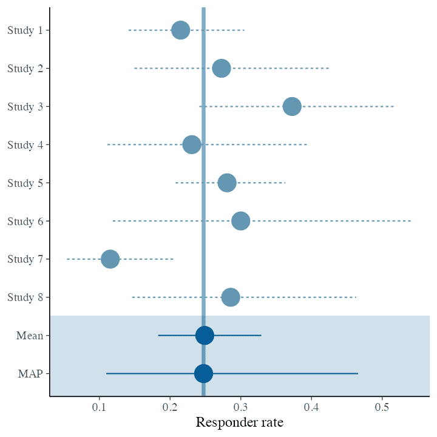

MAP prior:

| mean | sd | 2.5% | 50% | 97.5% |
| --- | --- | --- | --- | --- |
| 0.26 | 0.09 | 0.11 | 0.25 | 0.47 |

[^3]: D. Beaten, Lancet, 2013 (382)

## Generalized Meta-Analytic-Predictive model

$Y$ is the (control) group summary data for $H$ historical trials
$$\begin{align*}
Y_{h}|\theta_{h} &\sim f(\theta_{h}) & \forall \; h \in [1,H] \\
Y_\ast|\theta_\ast &\sim f(\theta_\ast) & \text{for new trial}
\end{align*}$$

**Exchangeability assumption**:
$$\begin{align*}
g(\theta_{h})|\beta,\tau &\sim \text{Normal}(\beta, \tau^2) & \forall \; h \in [1,H] \\
g(\theta_\ast)|\beta,\tau &\sim \text{Normal}(\beta, \tau^2) & \text{for new trial}
\end{align*}$$

- $f$ likelihood / $g$ link function: Binomial/logit, Normal (known $\sigma$)/identity or Poisson/log
- $\tau \rightarrow 0 \Rightarrow$ pooling / unbound use of historical data
- $\tau \rightarrow \infty \Rightarrow$ stratification / no use of historical data

## Running the MAP analysis in R

- `RBesT`<sup>1</sup>

```r
library(RBesT)
set.seed(98721487)
map_mc <- gMAP(cbind(r, n-r) ~ 1 | study,
               data=RBesT::AS,
               family=binomial,
               tau.dist="HalfNormal",
               tau.prior=1,
               beta.prior=2)
```

- `brms`

```r
library(brms)
# outcome modifier "| trials(n)" to specify number of trials
# intercept study random effect requested with (1 | study)
bmap_model <- bf(r | trials(n) ~ 1 + (1 | study),
                 family=binomial, center=FALSE)
bmap_model_prior <- prior(normal(0, 2), class=b, coef=Intercept) +
    prior(normal(0, 1), class=sd, coef=Intercept, group=study)
bmap_mc <- brm(bmap_model,
               data=RBesT::AS,
               prior=bmap_model_prior,
               seed=98721487, control=list(adapt_delta=0.99))
```

| study | n | r |
| --- | --- | --- |
| Study 1 | 107 | 23 |
| Study 2 | 44 | 12 |
| Study 3 | 51 | 19 |
| Study 4 | 39 | 9 |
| Study 5 | 139 | 39 |
| Study 6 | 20 | 6 |
| Study 7 | 78 | 9 |
| Study 8 | 35 | 10 |

[^4]: R Bayesian evidence synthesis tools, https://opensource.nibr.com/RBesT/

## `brms` generated Stan code & data

```r
stancode(bmap_mc)
```

```stan
// generated with brms 2.23.0
functions {
}
data {
  int<lower=1> N;  // total number of observations
  array[N] int Y;  // response variable
  array[N] int trials;  // number of trials
  int<lower=1> K;  // number of population-level effects
  matrix[N, K] X;  // population-level design matrix
  // data for group-level effects of ID 1
  int<lower=1> N_1;  // number of grouping levels
  int<lower=1> M_1;  // number of coefficients per level
  array[N] int<lower=1> J_1;  // grouping indicator per observation
  // group-level predictor values
  vector[N] Z_1_1;
  int prior_only;  // should the likelihood be ignored?
}
transformed data {
}
parameters {
  vector[K] b;  // regression coefficients
  vector<lower=0>[M_1] sd_1;  // group-level standard deviations
  array[M_1] vector[N_1] z_1;  // standardized group-level effects
}
transformed parameters {
  vector[N_1] r_1_1;  // actual group-level effects
  // prior contributions to the log posterior
  real lprior = 0;
  r_1_1 = (sd_1[1] * (z_1[1]));
  lprior += normal_lpdf(b[1] | 0, 2);
  lprior += normal_lpdf(sd_1[1] | 0, 1)
    - 1 * normal_lccdf(0 | 0, 1);
}
model {
  // likelihood including constants
  if (!prior_only) {
    // initialize linear predictor term
    vector[N] mu = rep_vector(0.0, N);
    mu += X * b;
    for (n in 1:N) {
      // add more terms to the linear predictor
      mu[n] += r_1_1[J_1[n]] * Z_1_1[n];
    }
    target += binomial_logit_lpmf(Y | trials, mu);
  }
  // priors including constants
  target += lprior;
  target += std_normal_lpdf(z_1[1]);
}
generated quantities {
}
```

```r
standata(bmap_mc)
```

```
$N
[1] 8

$Y
[1] 23 12 19  9 39  6  9 10

$trials
[1] 107  44  51  39 139  20  78  35

$K
[1] 1

$X
  Intercept
1         1
2         1
3         1
4         1
5         1
6         1
7         1
8         1
attr(,"assign")
[1] 0

$Z_1_1
1 2 3 4 5 6 7 8
1 1 1 1 1 1 1 1

$J_1
[1] 1 2 3 4 5 6 7 8

$N_1
[1] 8

$M_1
[1] 1

$NC_1
[1] 0

$prior_only
[1] 0

attr(,"class")
[1] "standata" "list"
```

## Summary MAP prior model

```r
summary(bmap_mc)
```

```
 Family: binomial
  Links: mu = logit
Formula: r | trials(n) ~ 1 + (1 | study)
   Data: RBesT::AS (Number of observations: 8)

Multilevel Hyperparameters:
~study (Number of levels: 8)
              Estimate Est.Error l-95% CI u-95% CI Rhat Bulk_ESS Tail_ESS
sd(Intercept)     0.38      0.21     0.06     0.86 1.00     1186     1616

Regression Coefficients:
          Estimate Est.Error l-95% CI u-95% CI Rhat Bulk_ESS Tail_ESS
Intercept    -1.10      0.19    -1.48    -0.72 1.00     1442     1530
```

- `Intercept` is the typical trial response rate on the logit scale
- `sd(Intercept)` is the between-trial heterogeneity $\tau$

## Predicting the placebo response rate in a new study

```r
AS_new <- data.frame(study = "new_study", n = 1)
pe <- posterior_epred(
    bmap_mc, newdata = AS_new,
    allow_new_levels = TRUE,
    sample_new_levels = "gaussian"
)
posterior_summary(pe)
```

```
      Estimate  Est.Error     Q2.5     Q97.5
[1,] 0.2585929 0.08815447 0.109296 0.4732844
```

- `allow_new_levels=TRUE` allows to simulate the study random effect for new (unseen) studies
- `sample_new_levels = "gaussian"` ensures that the simulation is done using the normal hierarchical model (the default is to *bootstrap* existing levels)

## Approximation with a finite mixture

For specifying the prior as part of a pre-specified analysis we choose a parametric approximation:

```r
pe_mix <- RBesT::automixfit(pe[, 1], type = "beta")
print(pe_mix, digits=3)
```

```
EM for Beta Mixture Model
Log-Likelihood = 4407.352

Univariate beta mixture
Mixture Components:
  comp1 comp2
w  0.67  0.33
a 16.64  2.99
b 50.26  7.71
```

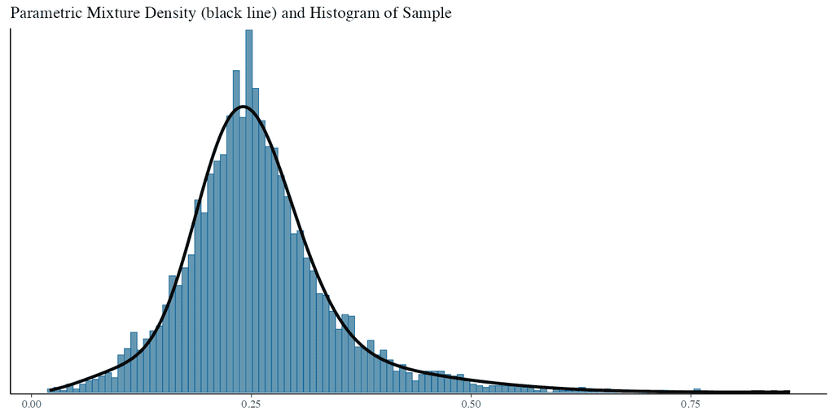

```r
plot(pe_mix)$mix
```

## Region specific MAP prior (hypothetically)

```r
withr::with_seed(654873,
                 AS_region <- bind_cols(AS, region=sample(c("asia", "europe", "north_america"), 8, TRUE)))
kable(AS_region)
```

| study | n | r | region |
| --- | --- | --- | --- |
| Study 1 | 107 | 23 | europe |
| Study 2 | 44 | 12 | asia |
| Study 3 | 51 | 19 | europe |
| Study 4 | 39 | 9 | europe |
| Study 5 | 139 | 39 | asia |
| Study 6 | 20 | 6 | north_america |
| Study 7 | 78 | 9 | europe |
| Study 8 | 35 | 10 | asia |

## Region specific MAP Priors via varying regions model

```r
form_AS_region <- bf(r | trials(n) ~ 1 + (1 | region/study),
                     family = binomial, center=FALSE)

# show which priors brms defines for this model
get_prior(form_AS_region, AS_region)

bprior_AS_region <- prior(normal(0, 2), class=b, coef=Intercept) +
  prior(normal(0, 0.8), class=sd, coef=Intercept, group=region) +
  prior(normal(0, 0.6), class=sd, coef=Intercept, group=region:study)

fit_AS_region <- brm(
  form_AS_region, data = AS_region, prior = bprior_AS_region, seed = 29856341,
  control=list(adapt_delta=0.99))
```

- `(1 | region/study)` specifies a *nested* random effect as each study is run in a single region. It is equivalent to  
  `(1 | region) + (1 | region:study)`.

## Summary region model

```r
summary(fit_AS_region)
```

```
 Family: binomial
  Links: mu = logit
Formula: r | trials(n) ~ 1 + (1 | region/study)
   Data: AS_region (Number of observations: 8)

Multilevel Hyperparameters:
~region (Number of levels: 3)
              Estimate Est.Error l-95% CI u-95% CI Rhat Bulk_ESS Tail_ESS
sd(Intercept)     0.36      0.32     0.01     1.19 1.00     1360     1596

~region:study (Number of levels: 8)
              Estimate Est.Error l-95% CI u-95% CI Rhat Bulk_ESS Tail_ESS
sd(Intercept)     0.34      0.19     0.03     0.77 1.00     1109      989

Regression Coefficients:
          Estimate Est.Error l-95% CI u-95% CI Rhat Bulk_ESS Tail_ESS
Intercept    -1.07      0.33    -1.69    -0.33 1.00     1792     1879
```

## Extract MAP MCMC samples

```r
AS_region_new <- data.frame(study = "new_study_asia",
                            n = 1, region = "asia")

pe_region <- posterior_epred(
  fit_AS_region, newdata = AS_region_new,
  allow_new_levels = TRUE,
  sample_new_levels = "gaussian"
)
dim(pe_region)
```

```
[1] 4000    1
```

```r
posterior_summary(pe_region)
```

```
      Estimate  Est.Error      Q2.5     Q97.5
[1,] 0.2734754 0.08718665 0.1215381 0.4799224
```

## Obtain parametric MAP prior

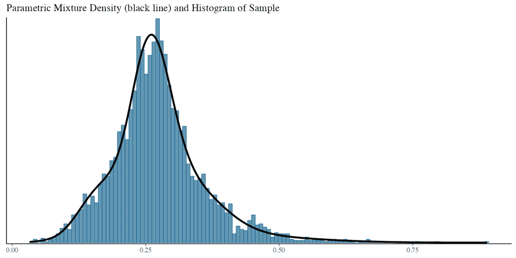

```r
pe_mix_region <- RBesT::automixfit(pe_region[, 1], type = "beta")
plot(pe_mix_region)$mix
```

## Summary historical control data

- Bayesian random-effects meta-analysis models can be used to derive Meta-Analytic-Predictive (MAP) priors
- Predictions for new study mean inform the MAP prior
- Specification and inference for MAP models is simple in `brms`
- Not covered here:
  - Parametric MAP mixtures can be used as priors in `brms` using the `RBesT::mixstanvar` adapter ([check its documentation](https://opensource.nibr.com/RBesT/reference/mixstanvar.html)), also refer to the case study [Use of historical control data with stratification](https://opensource.nibr.com/bamdd/src/02ac_meta_analysis_strata.html)
  - Prior setup, coming up next and also refer to [model description](https://opensource.nibr.com/bamdd/src/02a_meta_analysis.html#model-description) section of respective historical control case study

# Hands-on exercises: historical control data

# Priors

## The prior can only be understood in the context of the model <sup>1</sup>

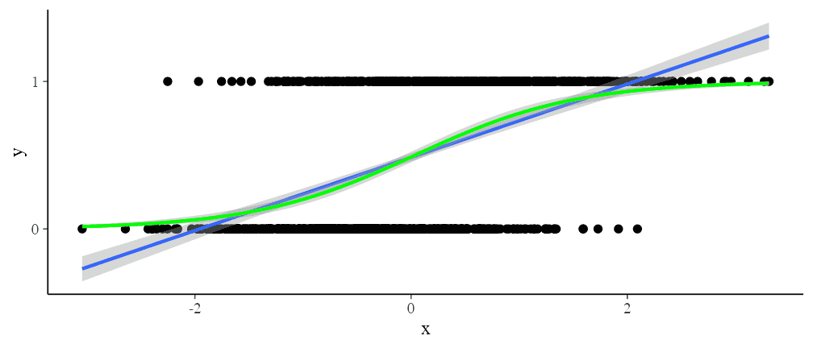

[^5]: Further reading: Gelman, A., Simpson, D., & Betancourt, M. (2017). The prior can often only be understood in the context of the likelihood. *Entropy*.

## Commonly heard reasons to be afraid of priors

“Priors are inherently subjective”

“Priors bias your analysis”

“You should let the data speak for themselves”

“Non-Bayesian models don’t have priors and don’t need them”

“I have no idea how to set appropriate priors”

## Are priors inherently subjective?

Consider using the alternative terms “contextual” or “conditional”<sup>1</sup>

- on the person or people or agent performing the analysis
- on results of previous studies
- on structural assumptions
- …
[^6]: Further reading: Christen, J. A. (2006). Stop using ‘subjective’ to refer to Bayesian analyses (comment on articles by Berger and by Goldstein). *Bayesian Analysis*.

## Do priors bias your analysis?

*Definition*:

An estimator $\hat{\theta}$ of the parameter $\theta$ is called *unbiased* if $\text{E}_{y}(\hat{\theta}) = \theta$.

*Corrollary*:

If an estimator $\hat{\theta}$ is unbiased for a given prior, it will be biased for most other priors.

*Corrollary*:

If an estimator $\hat{\theta}$ is unbiased at a given scale, it will be biased for most non-linear transformations $f(\hat{\theta})$ (Jensen’s inequality):
$$\text{E}_y(f(\hat{\theta})) \neq f(\theta)$$

**Unbiasedness is fragile and often only holds in the limit**

## Is bias even the right metric?

A sampling distribution is a distribution of a data-dependent variable (a “statistic”) as implied by variation in data $y$ across the true data generating process

Consider two estimators $\hat{\theta}_1$ and $\hat{\theta}_2$ of $\theta$ with sampling distributions given by

- $p(\hat{\theta}_1) := p(\hat{\theta}_1(y)) = \text{Normal}(\theta, 10)$
- $p(\hat{\theta}_2) := p(\hat{\theta}_2(y)) = \text{Normal}(\theta + 0.2, 1)$

Which of them is better?

## Winning the bias-variance trade-off

The RMSE can be defined as
$$\begin{align*}
\text{RMSE}_y(\hat{\theta}, \theta) & = \sqrt{\int (\hat{\theta}(y) - \theta)^2 \; p(y) \; d y} \\
& = \sqrt{\text{Var}_y{\hat{\theta}} + \text{Bias}_y(\hat{\theta}, \theta) ^2}
\end{align*}$$

It expresses a trade-off between variance and bias

A lot of priors will help you win the bias-variance trade-off, not the race for minimal bias!

## Non-Bayesian models don’t have priors?

Basic multilevel model with $J$ groups:

```r
y ~ normal(b0[j] + b1 * x, sigma)
b0[j] ~ normal(b0, sd0)
```

Is `b0[j] ~ normal(b0, sd0)` a likelihood, prior, or something else?

## “Non-informative” uniformity is informative!

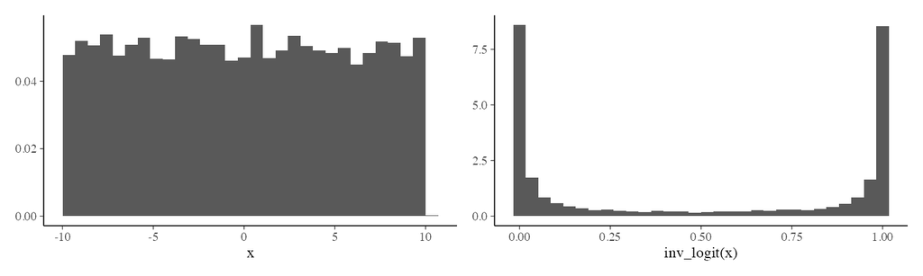

## Principles of specifying priors

- Respecting boundaries: use hard bounds in priors exactly where parameters have natural bounds
- Expressiveness: use prior families flexible enough to express different plausible prior knowledge
- Controlling complexity: If you want to be conservative, put relevant amount of prior probability at or near a conservative submodel
- Scale awareness: ensure that priors take the scales and measurement unit of parameters into account
- Reflecting structure: reflect the structure of the data in the structure of the prior
- **Data Informed**: Use previous data to inform the current priors

## Data informed priors

- The [`RBesT` package](https://opensource.nibr.com/RBesT/) allows to build Meta-Analytic-Predictive (MAP) priors, a special kind of data informed priors
- See the ESMARConf2023 tutorial for `RBesT` on [Youtube](https://www.youtube.com/watch?v=w90j-PLwWDc)
- Also check out https://opensource.nibr.com/bamdd/ for the following MAP case studies: [**historical control** without](https://opensource.nibr.com/bamdd/src/02a_meta_analysis.html) / [with **stratification**](https://opensource.nibr.com/bamdd/src/02ac_meta_analysis_strata.html), [treatment effects](https://opensource.nibr.com/bamdd/src/02ab_meta_analysis_trtdiff.html), [**single arm PoS**](https://opensource.nibr.com/bamdd/src/02l_single_arm_pos.html)

## Evaluating and comparing priors

- Consider the **unit** of a parameter
- Visualize the prior
- Categorization of parameter into **ranges**
- Comparisons of priors through  
  **interval probabilities**

**Example:** Binary response rates for a non-rare or frequent event

| Category | Percentage range |
| --- | --- |
| Extreme | 0–1% & 99–100% |
| Very Small | 1–5% & 95–99% |
| Small | 5–10% & 90–95% |
| Moderate | 10% – 90% |

## Prior visualization of a log-odds intercept

Example default priors

**wide**

Normal($0$, $10^2$)

**`brms`**

Student-t($3$, $0$, $2.5^2$)

**`RBesT`**

Normal($0$, $2^2$)

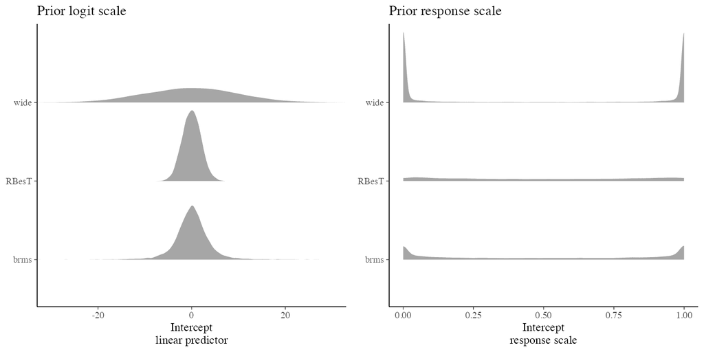

## Prior intervals of a log-odds intercept

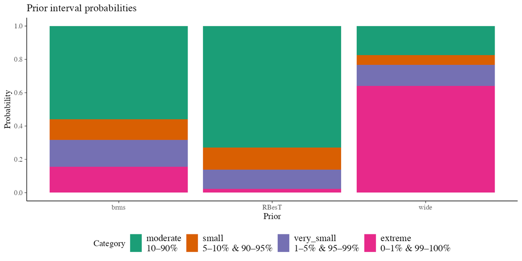

## Advanced: Prior tails

What is the posterior?

- … if the prior is
  $$\theta \sim \text{student-t}(4, 5, 1)$$
- … and the likelihood alone implies a posterior of
  $$\theta \sim \text{normal}(-5, 1)$$

## Student-t(4) prior vs. normal likelihood

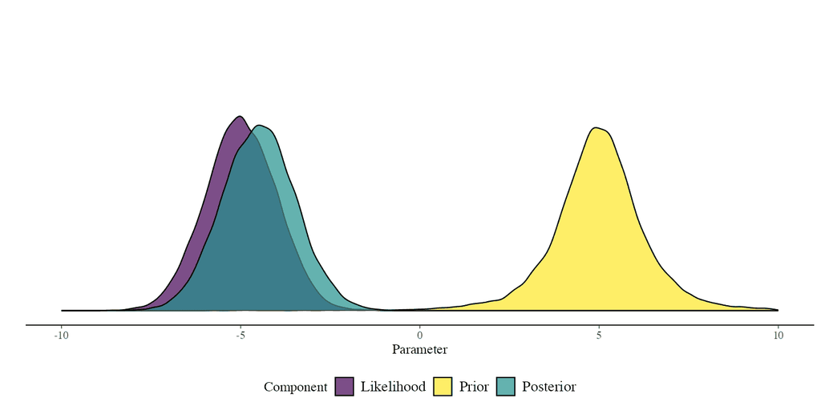

## Normal prior vs. student-t(4) likelihood

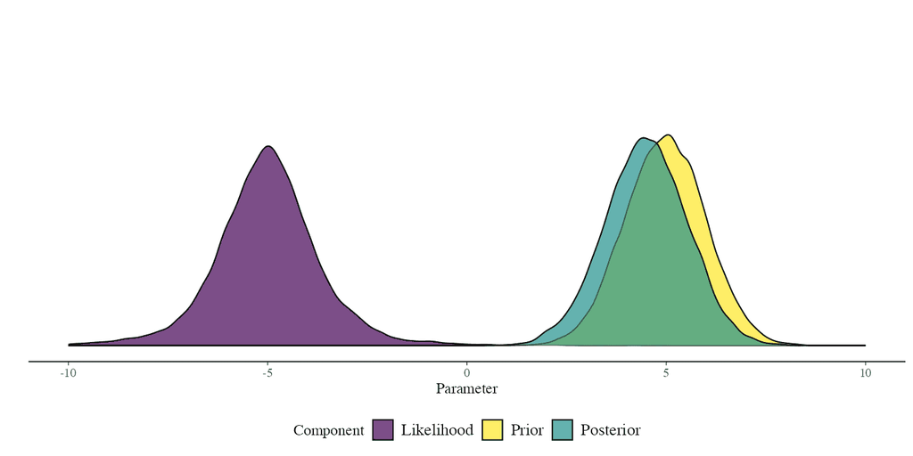

## Normal prior vs. normal likelihood

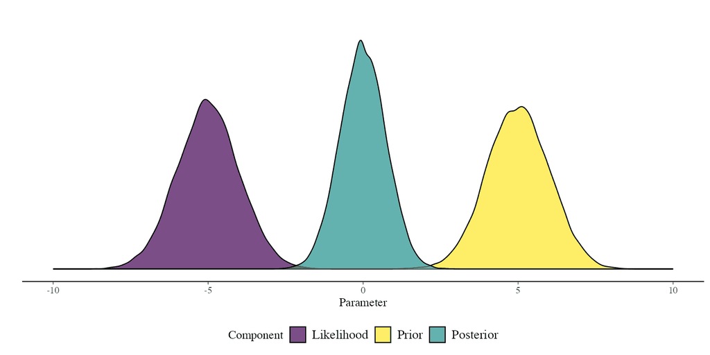

## Student-t(4) prior vs. student-t(4) likelihood

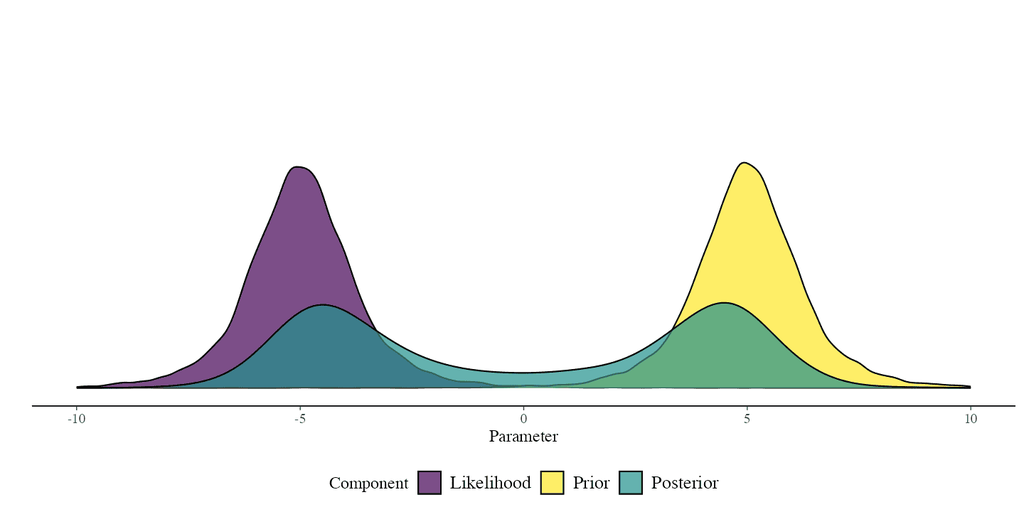

# Dose finding

## Typical dose response shapes

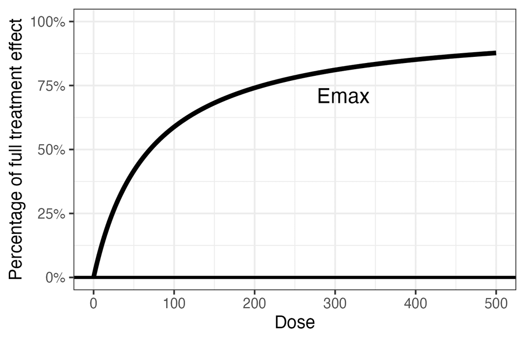

## Typical dose response shapes

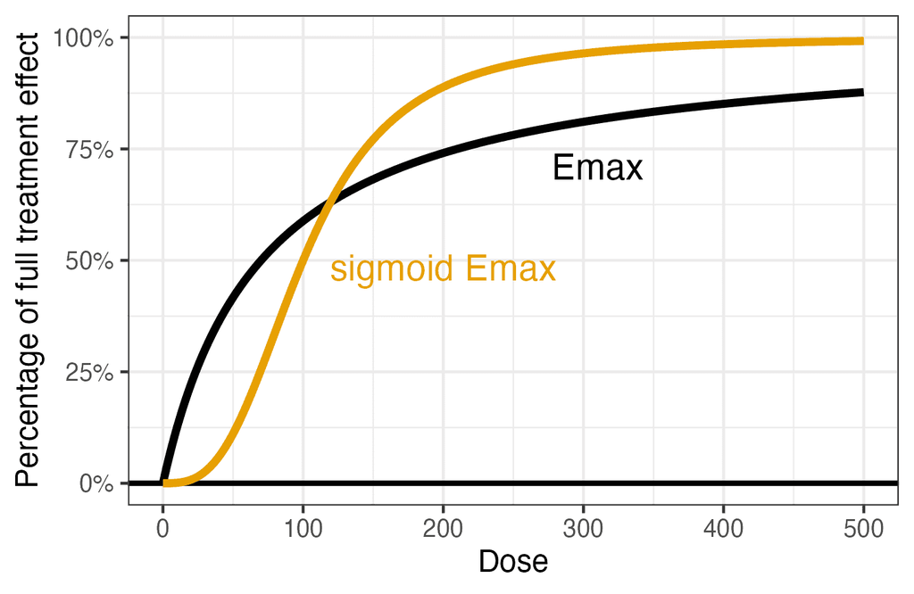

## Typical dose response shapes

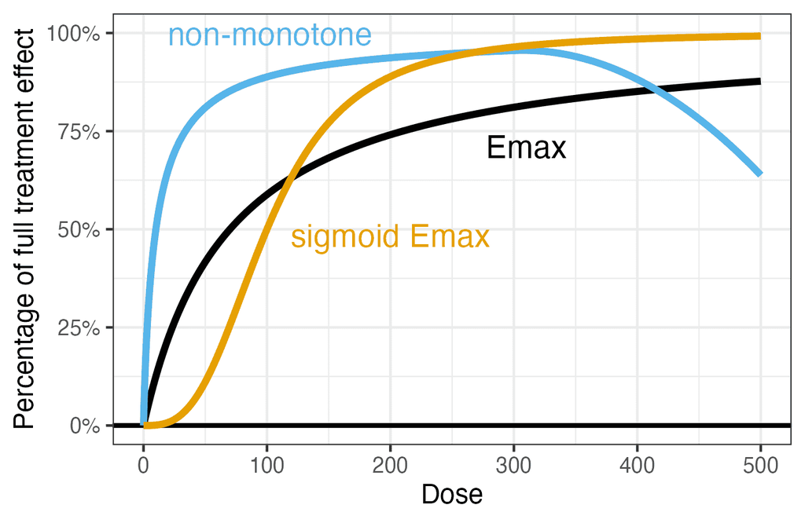

## Data Set PATHWAY

- Placebo controlled trial
- Treatment of severe asthma with tezepelumab
- Three different doses + placebo
- Endpoint: annualized rate of asthma exacerbations
- Estimates per arm from negative binomial regression (like in “arm-based meta-analysis”), not individual patient data

| dose | group | log_est | log_stderr |
| --- | --- | --- | --- |
| 0 | placebo | −0.400 | 0.103 |
| 70 | tezepelumab 70 mg q4w | −1.347 | 0.177 |
| 210 | tezepelumab 210 mg q4w | −1.661 | 0.222 |
| 560 | tezepelumab 280 mg q2w | −1.514 | 0.191 |

## Sigmoid E<sub>max</sub> Model

$$f(\text{dose}; \text{parameters}) = \text{E}_0 + \text{E}_\text{max} \frac{\text{dose}^h}{\text{dose}^h + \text{ED}_{50}^h}$$

Parameters:

- $\text{E}_0 \in \mathbb{R}$: Expected placebo outcome
- $\text{E}_\text{max} \in \mathbb{R}$: Maximum effect size
- $h \in \mathbb{R}_+$: Hill (steepness) parameter
- $\text{ED}_{50}$: Dose at which 50% of $\text{E}_\text{max}$ is reached

## Sigmoid E<sub>max</sub> Model: Visualization

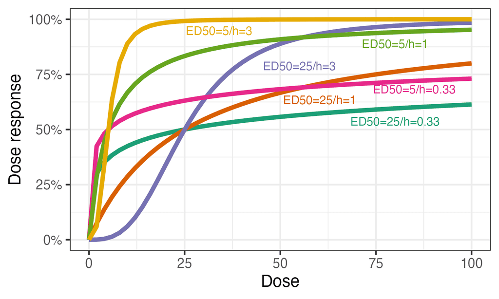

## Specifying sigmoid E<sub>max</sub> Model with `brms`

```r
form_sig <- bf(
  log_est | se(log_stderr) ~ E0 + Emax * dose^h /
                             (dose^h + ED50^h),
  nlf(h ~ exp(logh)), nlf(ED50 ~ exp(logED50)),
  E0 ~ 1, Emax ~ 1, logh ~ 1, logED50 ~ 1,
  nl = TRUE,
  family = gaussian()
)

prior_sig <- prior(normal(0,1), nlpar=E0) +
  prior(normal(0,1), nlpar=logh) +
  prior(normal(0,1), nlpar=Emax) +
  prior(normal(4,2), nlpar=logED50)
```

## A note on E<sub>max</sub> Model priors

What is more informative?

- $\text{logh} \sim \text{normal}(0,1)$
- $\text{logh} \sim \text{normal}(0,3)$

## A note on E<sub>max</sub> Model priors

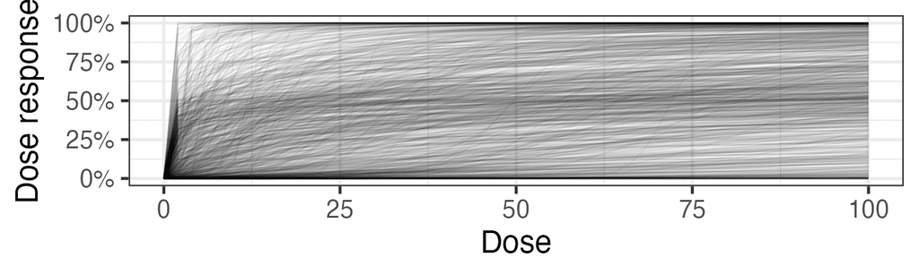

## A note on E<sub>max</sub> Model priors

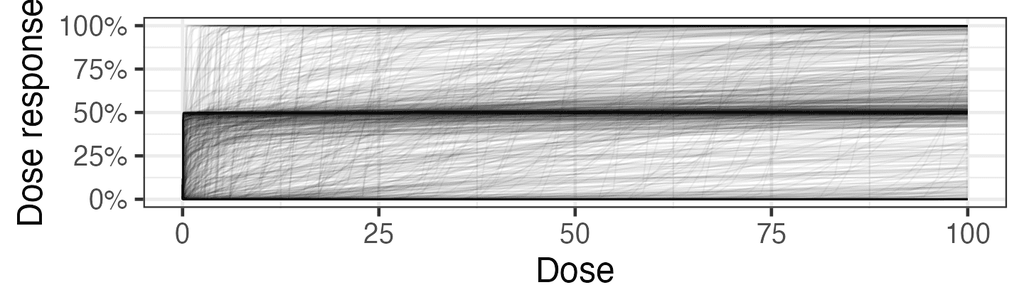

- Biologically plausible values: approx. $.25 < h < 4$ (see [prior interval probabilities](https://opensource.nibr.com/bamdd/src/01c_priors.html)).  
  The above prior puts roughly 1/3 above 4 and 1/3 below 0.25!
- Re-writing the fraction to $\left(\frac{d}{\text{ED}_{50}}\right)^h / \left(1+\left(\frac{d}{\text{ED}_{50}}\right)^h\right)$ makes it obvious that for $h \rightarrow 0$, this goes to $1/2$, and for $h \rightarrow \infty$, either to 0 ($d < \text{ED}_{50}$) or 1 ($d > \text{ED}_{50}$).

## Fitting the sigmoid E<sub>max</sub> Model with `brms`

```r
fit_sig <- brm(
  formula = form_sig,
  data = pathway,
  prior = prior_sig,
  control = list(adapt_delta = 0.999)
)
```

## Sigmoid E<sub>max</sub> Model: Results Summary

```r
summary(fit_sig)
```

```
 Family: gaussian
  Links: mu = identity
Formula: log_est | se(log_stderr) ~ E0 + Emax * dose^h/(dose^h + ED50^h)
         h ~ exp(logh)
         ED50 ~ exp(logED50)
         E0 ~ 1
         Emax ~ 1
         logh ~ 1
         logED50 ~ 1
   Data: pathway (Number of observations: 4)

Regression Coefficients:
                  Estimate Est.Error l-95% CI u-95% CI Rhat Bulk_ESS Tail_ESS
E0_Intercept         -0.41      0.10    -0.62    -0.21 1.00     1693     1931
Emax_Intercept       -1.28      0.30    -2.05    -0.83 1.00     1292     1162
logh_Intercept        0.01      0.99    -1.79     1.98 1.00     1327     1844
logED50_Intercept     2.63      1.43    -0.65     5.11 1.00     1311     1240

Further Distributional Parameters:
      Estimate Est.Error l-95% CI u-95% CI Rhat Bulk_ESS Tail_ESS
sigma     0.00      0.00     0.00     0.00   NA       NA       NA
```

## Visualizing the Fitted Sigmoid E<sub>max</sub> Model

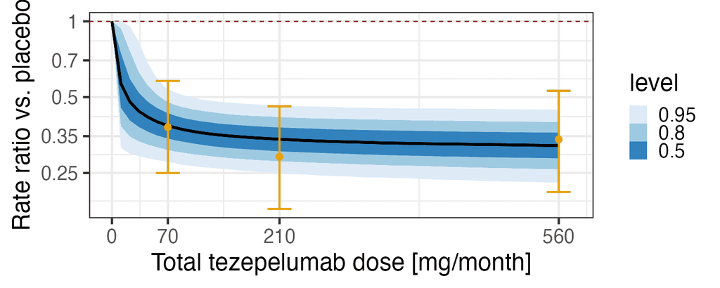

```r
tibble(dose = seq(0, 560, length.out=51), log_stderr=1) |>
  tidybayes::add_epred_rvars(object=fit_sig) |>
  mutate(.delta = .epred - .epred[dose == 0]) |>
  ggplot(aes(x=dose, ydist=.delta)) +
  ggdist::stat_lineribbon()
```

## Modified Beta Model

$$f(\text{dose}; \text{parameters}) = \text{E}_0 +
\text{E}_\text{max} \; \frac{(\delta_1 + \delta_2)^{(\delta_1+\delta_2)}} {\delta_1^{\delta_1} \, \delta_2^{\delta_2}} \; \left(\frac{\text{dose}}{S}\right)^{\delta_1} \left(1-\frac{\text{dose}}{S}\right)^{\delta_2}$$

Parameters:

- $\text{E}_0 \in \mathbb{R}$: Expected placebo response
- $\text{E}_\text{max} \in \mathbb{R}$: Maximum effect size
- $\delta_1, \delta_2 \in \mathbb{R}_+$: Shape parameters
- $S$: constant > maximum dose, e.g. $1.5 \times \max(\text{dose})$, here we choose `S=850`

## Specifying the Modified Beta Model with `brms`

```r
form_mbeta <- bf(
  log_est | se(log_stderr) ~ E0 +
    Emax * (delta1+delta2)^(delta1+delta2) /
    (delta1^delta1 * delta2^delta2) *
    (dose/850)^delta1 * (1-dose/850)^delta2,
  nlf(delta1 ~ exp(logdelta1)), nlf(delta2 ~ exp(logdelta2)),
  E0 ~ 1, Emax ~ 1, logdelta1 ~ 1, logdelta2 ~ 1,
  nl = TRUE,
  family = gaussian()
)

prior_mbeta <- prior(normal(0,1), nlpar="E0") +
  prior(normal(0,1), nlpar="Emax") +
  prior(normal(0,1), nlpar="logdelta1") +
  prior(normal(0,1), nlpar="logdelta2")
```

## Fitting the Modified Beta Model with `brms`

```r
fit_mbeta <- brm(
  form_mbeta,
  data = pathway,
  prior = prior_mbeta,
  control = list(adapt_delta = 0.999)
)
```

## Visualizing the Fitted Modified Beta Model

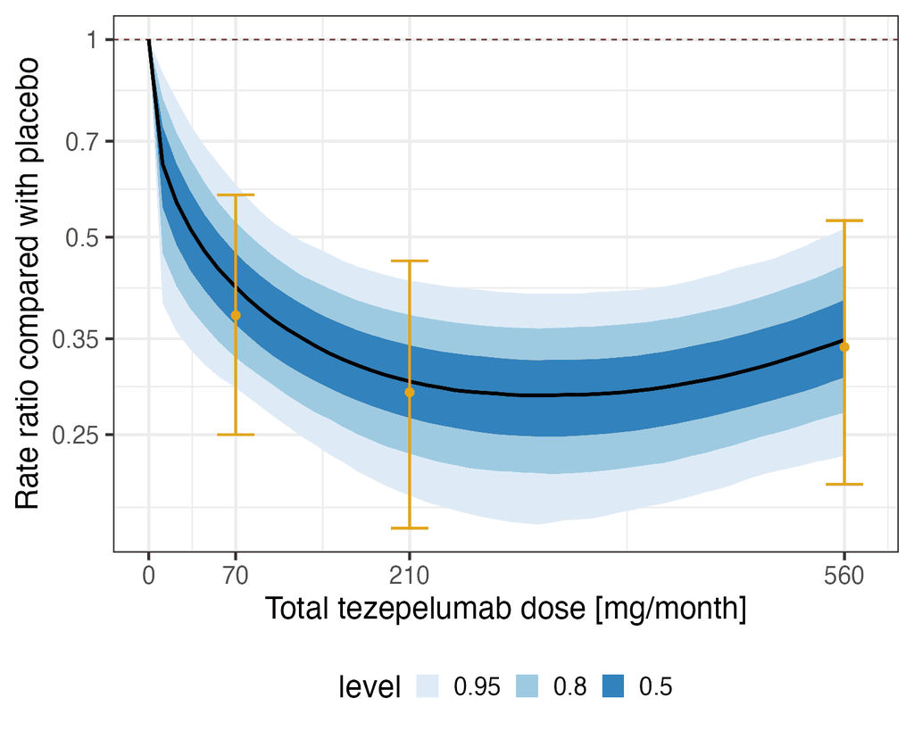

## Model Evaluation (failed attempt)

```r
(loo_mbeta <- loo(fit_mbeta))
```

```
Computed from 4000 by 4 log-likelihood matrix.

         Estimate  SE
elpd_loo      0.1 0.7
p_loo         2.1 0.5
looic        -0.3 1.3
------
MCSE of elpd_loo is NA.
MCSE and ESS estimates assume MCMC draws (r_eff in [0.4, 0.6]).

Pareto k diagnostic values:
                         Count Pct.    Min. ESS
(-Inf, 0.7]   (good)     2     50.0%   150
   (0.7, 1]   (bad)      2     50.0%   <NA>
   (1, Inf)   (very bad) 0      0.0%   <NA>
See help('pareto-k-diagnostic') for details.
```

- `brms` interfaces with the `loo` R package that performs efficient approximate leave-one-out cross-validation (LOO) for Bayesian models by Pareto smoothed importance sampling (PSIS). See [Vethari *et al.* (2017)](https://doi.org/10.1007%2Fs11222-016-9696-4) and the [`loo` documentation on CRAN](https://cran.r-project.org/package=loo).

## Model Evaluation (works)

```r
loo_exact_sig <- kfold(fit_sig, folds = "loo", silent=2)
(loo_exact_mbeta <- kfold(fit_mbeta, folds = "loo", silent=2))
```

```
Based on 4-fold cross-validation.

           Estimate  SE
elpd_kfold     -2.1 1.7
p_kfold         4.4 2.2
kfoldic         4.2 3.4
```

- **elpd_kfold**: CV estimate of the **expected log pointwise predictive density** for a new dataset
- **p_kfold**: CV estimate of difference between elpd_loo and the non-cross-validated log posterior predictive density (describes how much more difficult it is to predict future data than the observed data).
- **kfoldic**: -2 * elpd_kfold (on the conventional scale of deviance)

See the [LOO Glossary on mc-stan.org](https://mc-stan.org/loo/reference/loo-glossary.html) and [Vethari *et al.* (2017)](https://doi.org/10.1007/s11222-016-9696-4)

## Model Comparison

```r
loo_compare(loo_exact_sig, loo_exact_mbeta)
```

```
          elpd_diff se_diff
fit_sig    0.0       0.0
fit_mbeta -1.8       0.9
```

- `loo_compare` computes a paired estimate of the difference in ELPD to take advantage of the fact that the same set of data points was used to fit both models (and reduce the standard error). See [Vethari *et al.* (2017)](https://doi.org/10.1007/s11222-016-9696-4) and the [`loo` R package manual](https://cran.r-project.org/package=loo) for details.

```r
fit_sig$criteria$loo <- loo_exact_sig
fit_mbeta$criteria$loo <- loo_exact_mbeta
(w_dose <- model_weights(fit_sig, fit_mbeta, weights = "loo"))
```

```
  fit_sig fit_mbeta
0.8589718 0.1410282
```

- Here, `model_weights` from `brms` will compute Akaike weights based on the information criterion values returned by `loo`

## Bayesian Model Averaging

```r
pe_sig <- posterior_epred(fit_sig, newdata = dose_df)
pe_mbeta <- posterior_epred(fit_mbeta, newdata = dose_df)
pe_avg <- pe_sig * w_dose[1] + pe_mbeta * w_dose[2]
```

```r
pe_avg <- pe_avg |>
  posterior_summary() |>
  as.data.frame() |>
  bind_cols(dose_df)
```

```
    Estimate  Est.Error       Q2.5      Q97.5      dose
1 -0.4151540 0.09045093 -0.5904823 -0.2415002  0.000000
2 -0.8277490 0.27948258 -1.3727135 -0.3672984  5.656566
3 -0.9523345 0.27751337 -1.4428015 -0.4227625 11.313131
4 -1.0381309 0.26183898 -1.4743775 -0.4820924 16.969697
```

## Visualizing the Model Averaging

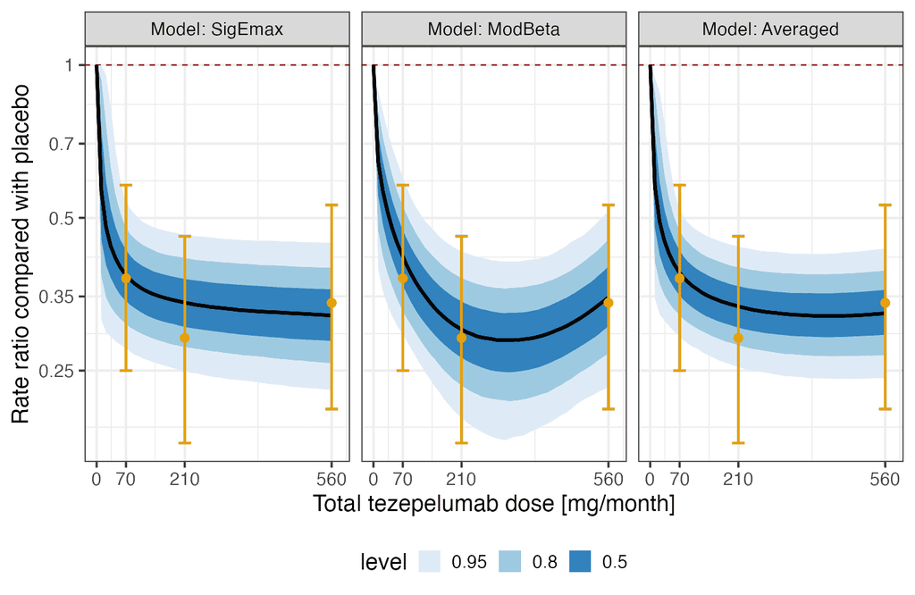

# Hands-on exercises: dose finding

# Bayesian Mixed Models for Repeated Measures

## Hypothetical dose finding study, N=200

Continuous outcome measured at baseline & weeks 2, 4, 8, 12

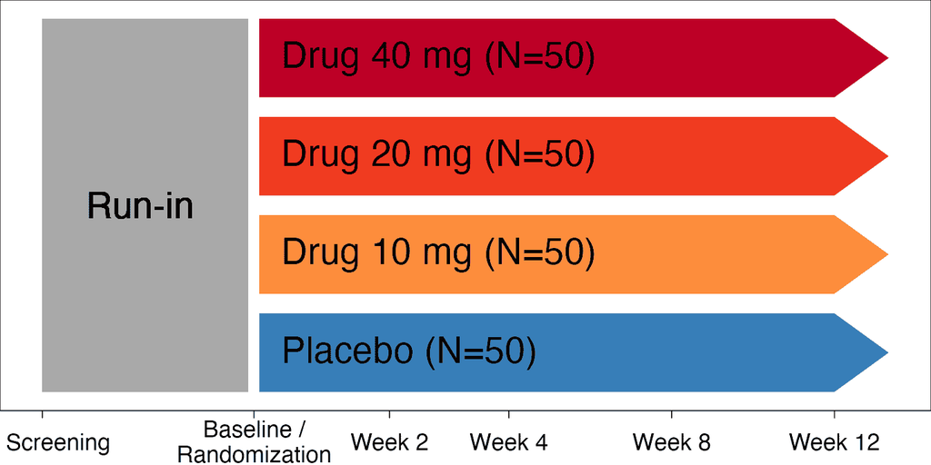

## Overview and Analysis Goals

- Mixed Effects Model for Repeated Measures (MMRM) commonly used for longitudinal data (each patient measured at multiple visits)
- Direct likelihood analysis that can address **hypothetical estimand of all patients completing** the study on treatment without doing missing data imputation first
- Commonly no structure assumed for correlations between visits and different variance allowed for different visits (to avoid unnecessary assumptions)
- Convergence issues with REML fit common, especially for small sample sizes, which is alleviated by Bayesian inference with (weakly-)informative priors
- Bayesian approach allows us to incorporate prior information and historical data, which is very interesting for Phase I studies
- `brms` lets us easily add more components & structure to the model

## What do our data look like?

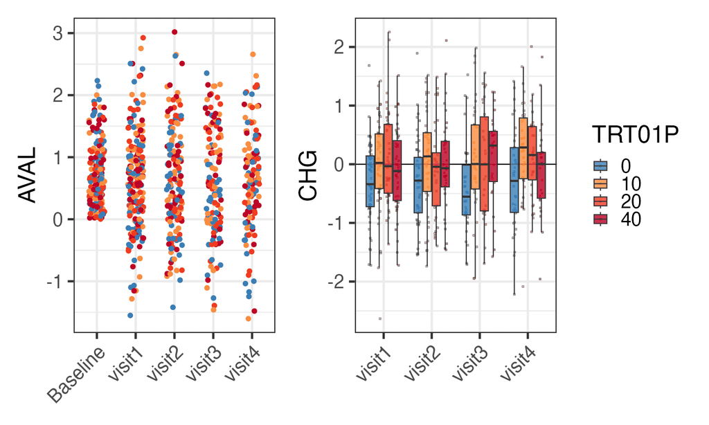

## Analysis Data Model (ADaM) Basic Data Structure (BDS)

| USUBJID | TRT01P | AVISIT | ADY | AVAL | CHG | BASE |
| --- | --- | --- | --- | --- | --- | --- |
| 3 | 40 | visit1 | 14 | 1.36 | 0.58 | 0.78 |
| 3 | 40 | visit2 | 28 | 1.17 | 0.40 | 0.78 |
| 3 | 40 | visit3 | 56 | −0.36 | −1.14 | 0.78 |
| 3 | 40 | visit4 | 84 | 1.35 | 0.58 | 0.78 |
| 9 | 10 | visit1 | 14 | 0.99 | 0.88 | 0.11 |
| 9 | 10 | visit2 | 28 | 1.33 | 1.22 | 0.11 |
| 9 | 10 | visit3 | 56 | −1.11 | −1.21 | 0.11 |
| 9 | 10 | visit4 | 84 | 1.14 | 1.04 | 0.11 |
| 13 | 0 | visit1 | 14 | 2.22 | 0.32 | 1.90 |
| 13 | 0 | visit2 | 28 | 1.62 | −0.28 | 1.90 |

> Patients can miss visits or drop-out of the study prior to the final visit.

## Model Specification: Informal (popular choice)

Fixed effects:

- baseline (pre-treatment) value of the endpoint
- visit as a factor
- treatment as a factor
- treatment by visit interaction
- visit by baseline value interaction

Random effects:

- Random subject effect on the visit main effect
- … or equivalently correlated residual error terms within subjects

## Model Specification: Formal

Formally, let us assume that there are $V$ visits. We assume that the $V$-dimensional response $\boldsymbol{Y}_i$ for patient $i$ satisfies
$$\boldsymbol{Y}_i = \boldsymbol{X}_i \boldsymbol{\beta} + \boldsymbol{Z}_i \boldsymbol{b}_i + \boldsymbol{\epsilon}_i$$

with $\boldsymbol{b}_i \sim \text{MVN}(\boldsymbol{0}, \boldsymbol{D})$ and $\boldsymbol{\epsilon}_i \sim \text{MVN}(\boldsymbol{0}, \boldsymbol{\Sigma})$, where $\boldsymbol{\Sigma}$ is a diagonal matrix. This implies
$$\boldsymbol{Y}_i \sim \text{MVN}(\boldsymbol{X}_i \boldsymbol{\beta}, \boldsymbol{V}_i),$$
where $\boldsymbol{V}_i = \boldsymbol{Z}_i \boldsymbol{D} \boldsymbol{Z}_i^T + \boldsymbol{\Sigma}$. Model the correlated $Y_{ij}$ either by

1. marginalizing out random effects & account for them with correlated residual errors (residual covariance matrix $V_i$), or
2. conditionally on (V-dimensional) random effects $\boldsymbol{b}_i$ with residual errors $\boldsymbol{\epsilon}_i$ independent (once we condition on $\boldsymbol{b}_i$).

## MMRMs in SAS

Widely-used high-quality reference implementation

```sas
PROC MIXED DATA=simulated_data;
  CLASS TRT01P AVISIT USUBJID;
  MODEL CHG ~ TRT01P AVISIT BASE TRT01P*AVISIT AVISIT*BASE
    / SOLUTION DDFM=KR ALPHA = 0.05;
  REPEATED AVISIT / TYPE=UN SUBJECT = USUBJID R Rcorr GROUP=TRT01P;
  LSMEANS TRT01P*AVISIT / DIFFS PDIFF CL OM E;
RUN;
```

## MMRMs with the `mmrm` R package

Fit the model in R in a frequentist framework

```r
library(mmrm)
mmrm_fit <- mmrm(
  formula = CHG ~ TRT01P + AVISIT + BASE + AVISIT:TRT01P +
    AVISIT:BASE + us(AVISIT | TRT01P / USUBJID),
  method = "Kenward-Roger",
  vcov = "Kenward-Roger-Linear", # to match SAS
  data = mutate(simulated_data, USUBJID=factor(USUBJID))
)
```

Refer to https://openpharma.github.io/mmrm.

## Motivation Forward Difference Parametrization

We would like to put priors on the differences from visit to visit

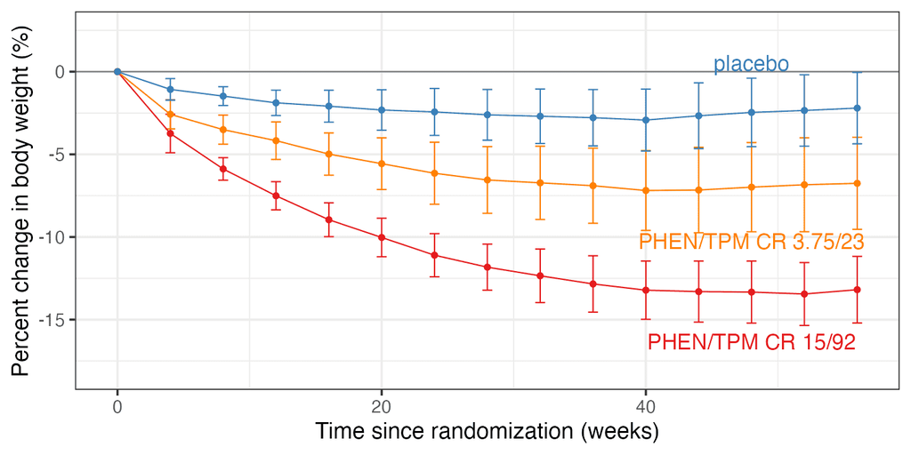

## Difference contrasts in R

Setup forward difference contrasts for changes between visits:

```r
contrasts(simulated_data$AVISIT) <- MASS::contr.sdif
```

Hard to interpret the contrast matrix directly:

```r
contrasts(simulated_data$AVISIT) |> MASS::fractions()
```

```
       visit2-visit1 visit3-visit2 visit4-visit3
visit1 -3/4          -1/2          -1/4
visit2  1/4          -1/2          -1/4
visit3  1/4           1/2          -1/4
visit4  1/4           1/2           3/4
```

Learn more about contrasts: https://bbolker.github.io/mixedmodels-misc/notes/contrasts.pdf

## What do these contrasts mean?

Inverting the contrast matrix reveals the dummy variables’ interpretation:

```r
# add the intercept
cmat <- cbind("Intercept" = 1, contrasts(simulated_data$AVISIT))
# compute the inverse matrix
solve(cmat) |> MASS::fractions()
```

```
              visit1 visit2 visit3 visit4
Intercept     1/4    1/4    1/4    1/4
visit2-visit1  -1      1      0      0
visit3-visit2   0     -1      1      0
visit4-visit3   0      0     -1      1
```

## MMRMs in `brms`

```r
mmrm_model1 <- bf(
  CHG ~ 1 + AVISIT + BASE + BASE:AVISIT + TRT01P + TRT01P:AVISIT
    + unstr(time = AVISIT, gr = USUBJID),
  sigma ~ 1 + AVISIT + TRT01P + AVISIT:TRT01P
)
```

```r
mmrm_prior1 <- prior(normal(0, 2), class=Intercept) +
    prior(normal(0, 1), class=b) +
    prior(normal(0, log(10.0)/1.64), class=Intercept, dpar=sigma) +
    prior(normal(0, log(2.0)/1.64), class=b, dpar=sigma) +
    prior(lkj(1), class=cortime)
```

```r
fit_mmrm1 <- brm(
  formula = mmrm_model1, data = simulated_data, prior = mmrm_prior1, ...
)
```

Note that a single **corrleation matrix** is estimated while the **covariance** varies as per the `sigma` model.

## Expected marginal (least-squares) means

```r
emm2 <- emmeans(fit_mmrm1, ~ TRT01P | AVISIT, weights="proportional")
```

```
AVISIT = visit1:
 TRT01P   emmean lower.HPD upper.HPD
 0      -0.25528   -0.4270   -0.0703
 10      0.00049   -0.2151    0.2118
 20      0.07641   -0.1520    0.2843
 40     -0.07090   -0.2577    0.1459

AVISIT = visit4:
 TRT01P   emmean lower.HPD upper.HPD
 0      -0.19978   -0.4838    0.0572
 10      0.21385   -0.0343    0.4832
 20      0.13390   -0.1356    0.4068
 40     -0.04110   -0.3468    0.2730

Point estimate displayed: median
HPD interval probability: 0.95
```

To work with MCMC samples of the expected marginal means & to summarize them exactly as we want (e.g. quantile credible intervals instead of highest posterior density intervals) we can use:

```r
emm2 |> as.mcmc() |> summarize_draws()
```

## Expected Marginal Contrasts per Visit

```r
contrast(emm2, adjust="none", method="trt.vs.ctrl", ref="TRT01P0")
```

```
AVISIT = visit1:
 contrast           estimate lower.HPD upper.HPD
 TRT01P10 - TRT01P0    0.257   -0.0158     0.530
 TRT01P20 - TRT01P0    0.328    0.0375     0.616
 TRT01P40 - TRT01P0    0.186   -0.0858     0.442

AVISIT = visit4:
 contrast           estimate lower.HPD upper.HPD
 TRT01P10 - TRT01P0    0.412    0.0546     0.792
 TRT01P20 - TRT01P0    0.336   -0.0497     0.715
 TRT01P40 - TRT01P0    0.161   -0.2615     0.558

Point estimate displayed: median
HPD interval probability: 0.95
```

`as.mcmc()` to work with MCMC samples of the difference, e.g.

```r
contrast(emm2, adjust="none", method="trt.vs.ctrl", ref="TRT01P0") |> as.mcmc()
```

## Monotonic Effects Across Ordered Factor Levels

```r
mmrm_model2 <- bf(
  CHG ~ 1 + AVISIT + mo(TRT01P) + BASE + mo(TRT01P):AVISIT
    + BASE:AVISIT + unstr(time = AVISIT, gr = USUBJID),
  sigma ~1 + AVISIT + mo(TRT01P) + mo(TRT01P):AVISIT
)
```

For category $c=0,\ldots,(\text{categories}-1) = C-1$, the monotonic term is
$$\text{coefficient} \times (C-1) \times \sum_{k=1}^{c} \zeta_k$$

- $\zeta_k \in [0, 1]$ is the percent increase and is subject to the constraint $\sum_{k=1}^{C-1} \zeta_k = 1$
- $\text{coefficient}$ is the mean change between adjacent categories

For more details see the respective vignette:  
https://paulbuerkner.com/brms/articles/brms_monotonic.html

```r
fit_mmrm2 <- brm(formula = mmrm_model2,
                 data = simulated_data |> mutate(TRT01P=ordered(TRT01P)), prior = mmrm_prior1, ...)
```

## Results from different MMRMs

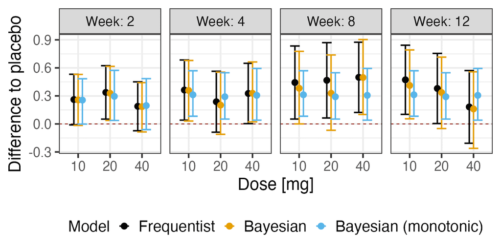

## MMRMs: Outlook

In the online case study on http://opensource.nibr.com/bamdd you additionally find:

- Data and full code
- More on estimands, parametrization, contrasts & priors
- Estimating average differences across visits
- Meta-analytic combined (MAC) using historical data
- Robustifying MAC via a “slab-and-spike”-type prior
- Non-linear functions over time & doses in MMRMs
- Excercises

# Longitudinal data

## Longitudinal Data: Background

- Example: simulated study of a drug for the treatment of Psoriasis
- 112 patients, 59 randomized to placebo, 53 to drug.
- Efficacy was assessed using the Psoriasis Area and Severity Index (PASI), a numerical score which measures the severity and extent of psoriasis (0: no disease, 72: maximum).
- Assessed at baseline and 7 post-baseline timepoints.

## Longitudinal Data: Illustration

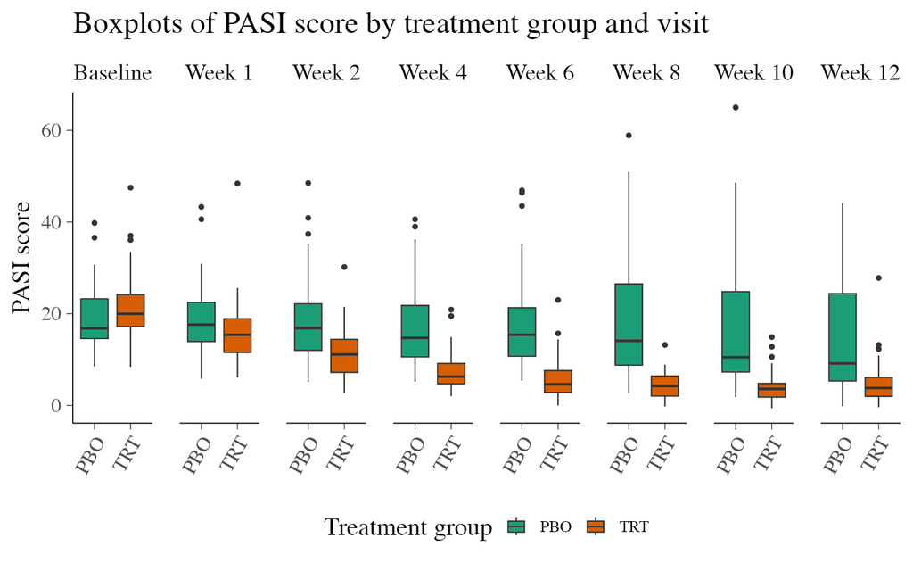

## Longitudinal Data: Key Variables

```
# A tibble: 10 × 6
      CHG  BASE TRT01P AVISIT  AVISITN SUBJID
    <dbl> <dbl> <fct>  <fct>     <dbl>  <dbl>
 1 -2.2    16   PBO    Week 1        1      1
 2 -0.5    16   PBO    Week 2        2      1
 3  4.7    16   PBO    Week 4        4      1
 4  7.3    16   PBO    Week 6        6      1
 5 32.1    16   PBO    Week 8        8      1
 6 10      16   PBO    Week 10      10      1
 7 20.7    16   PBO    Week 12      12      1
 8  3.4    20.3 TRT    Week 1        1      2
 9  1.2    20.3 TRT    Week 2        2      2
10  0.600  20.3 TRT    Week 4        4      2
```

…

## Longitudinal Data: Mean Model

```r
fit_long_mean <- brm(
  CHG ~ BASE + TRT01P * AVISIT + (1 | SUBJID),
  data = pasi_data, seed = 2454
)
fit_long_mean <- add_criterion(fit_long_mean, "loo")
```

Total elapsed fitting time (seconds):

```r
sum(rstan::get_elapsed_time(fit_long_mean$fit))
```

```
[1] 3.654
```

## Mean Model: Posterior predictive checks

```r
pp_check(fit_long_mean)
```

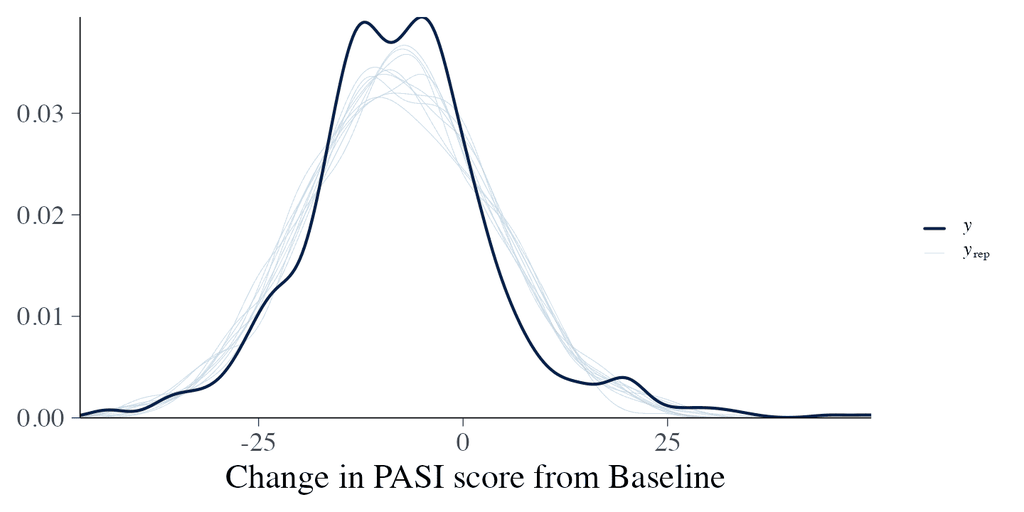

- `pp_check` in `brms` performs posterior predictive checks with the help of the `bayesplot` package (shows `dens_overlay` by default).
  - Can also be called with type `loo_pit_qq` (probability integral transformation). In an ideal model fit, the resulting PIT-transformed values would be uniformly distributed: i.e. the blue points and dashed lines would align with the distribution function of a Uniform(0,1) variable (solid line). See [chapter 12 of BAMDD](https://opensource.nibr.com/bamdd/src/02g_longitudinal.html#assessing-model-fit) for details.

## Mean Model: LOO-CV results

```r
loo(fit_long_mean)
```

```
Computed from 4000 by 684 log-likelihood matrix.

         Estimate   SE
elpd_loo  -2285.7 33.1
p_loo       101.9  9.5
looic      4571.4 66.3
------
MCSE of elpd_loo is NA.
MCSE and ESS estimates assume MCMC draws (r_eff in [0.4, 1.8]).

Pareto k diagnostic values:
                         Count Pct.    Min. ESS
(-Inf, 0.7]   (good)     681   99.6%   103
   (0.7, 1]   (bad)        3    0.4%   <NA>
   (1, Inf)   (very bad)   0    0.0%   <NA>
See help('pareto-k-diagnostic') for details.
```

- While this is quick, is this what we are interested in?
  - If we’re interested in the prediction for a new (unseen) patient, we should be running leave-one-patient-out CV (not leave-one-observation-out)…  
    See `kfold_split_grouped` in the `loo` package.
  - For the E<sub>max</sub> model data: not possible (IPD needed!)

## Mean Model: Visualization of effects

```r
conditional_effects(fit_long_mean, "AVISIT:TRT01P")
```

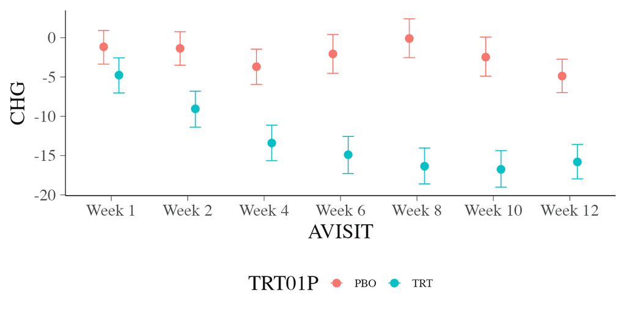

- By default, numeric variables will be conditionalized by using their means and factors will get their first level assigned.
- We might be interested in the effect integrated out over a population $\rightarrow$ `emmeans`
  - See longitudinal data exercise 1 in [BAMDD Chapter 12](https://opensource.nibr.com/bamdd/src/02g_longitudinal.html#exercises)

## Longitudinal Data: Linear Model

```r
fit_long_lin <- brm(
  CHG ~ BASE + TRT01P * AVISITN + (1 | SUBJID),
  data = pasi_data, seed = 2454
)
fit_long_lin <- add_criterion(fit_long_lin, "loo")
```

Total elapsed fitting time:

```r
sum(rstan::get_elapsed_time(fit_long_lin$fit))
```

```
[1] 3.026
```

## Linear Model: Summary

```r
summary(fit_long_lin)
```

```
 Family: gaussian
  Links: mu = identity
Formula: CHG ~ BASE + TRT01P * AVISITN + (1 | SUBJID)
   Data: pasi_data (Number of observations: 684)

Multilevel Hyperparameters:
~SUBJID (Number of levels: 112)
              Estimate Est.Error l-95% CI u-95% CI Rhat Bulk_ESS Tail_ESS
sd(Intercept)     5.21      0.45     4.41     6.15 1.00     1358     2336

Regression Coefficients:
                  Estimate Est.Error l-95% CI u-95% CI Rhat Bulk_ESS Tail_ESS
Intercept            13.11      1.78     9.55    16.53 1.00     1567     2375
BASE                 -0.70      0.08    -0.85    -0.54 1.00     1502     2233
TRT01PTRT            -6.10      1.34    -8.74    -3.43 1.00     1497     2504
AVISITN              -0.22      0.09    -0.40    -0.04 1.00     3550     3397
TRT01PTRT:AVISITN    -0.72      0.13    -0.97    -0.47 1.00     3360     3063

Further Distributional Parameters:
      Estimate Est.Error l-95% CI u-95% CI Rhat Bulk_ESS Tail_ESS
sigma     6.52      0.19     6.15     6.91 1.00     4605     3086
```

## Linear Model: Visualization of effects

```r
conditional_effects(fit_long_lin, "AVISITN:TRT01P")
```

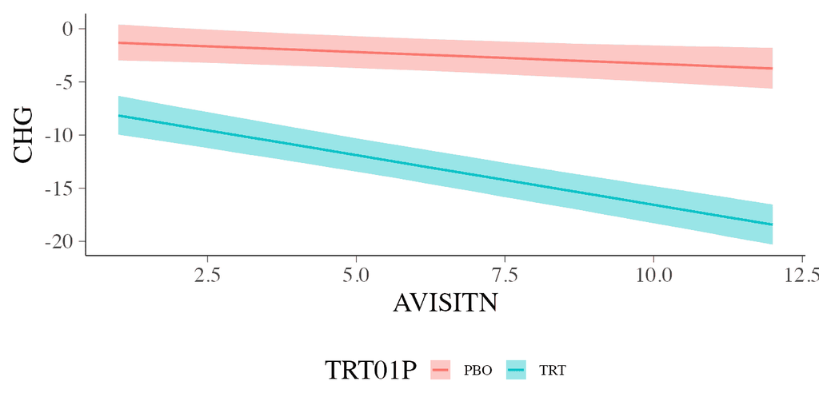

## Longitudinal Data: Linear Model with Varying Slopes

```r
fit_long_lin_vs <- brm(
  CHG ~ BASE + TRT01P * AVISITN + (1 + AVISITN | SUBJID),
  data = pasi_data, seed = 2454
)
fit_long_lin_vs <- add_criterion(fit_long_lin_vs, "loo")
```

Total elapsed fitting time:

```r
sum(rstan::get_elapsed_time(fit_long_lin_vs$fit))
```

```
[1] 8.619
```

## Linear Model: Summary

```r
summary(fit_long_lin_vs)
```

```
 Family: gaussian
  Links: mu = identity
Formula: CHG ~ BASE + TRT01P * AVISITN + (1 + AVISITN | SUBJID)
   Data: pasi_data (Number of observations: 684)

Multilevel Hyperparameters:
~SUBJID (Number of levels: 112)
                       Estimate Est.Error l-95% CI u-95% CI Rhat Bulk_ESS Tail_ESS
sd(Intercept)              5.26      0.53     4.28     6.32 1.00     1393     2805
sd(AVISITN)                1.10      0.09     0.94     1.28 1.00      708     1345
cor(Intercept,AVISITN)    -0.54      0.09    -0.70    -0.35 1.01      489      928

Regression Coefficients:
                  Estimate Est.Error l-95% CI u-95% CI Rhat Bulk_ESS Tail_ESS
Intercept             9.26      1.71     5.94    12.66 1.00     1294     1997
BASE                 -0.50      0.08    -0.65    -0.35 1.00     1052     1954
TRT01PTRT            -6.46      1.22    -8.92    -4.00 1.00     1883     2263
AVISITN              -0.24      0.16    -0.55     0.08 1.00      937     1943
TRT01PTRT:AVISITN    -0.72      0.24    -1.18    -0.24 1.00      818     1626

Further Distributional Parameters:
      Estimate Est.Error l-95% CI u-95% CI Rhat Bulk_ESS Tail_ESS
sigma     4.67      0.15     4.38     4.98 1.00     3159     3212
```

## Linear Model with Varying Slopes: Visualization of effects

```r
conditional_effects(fit_long_lin_vs, "AVISITN:TRT01P")
```

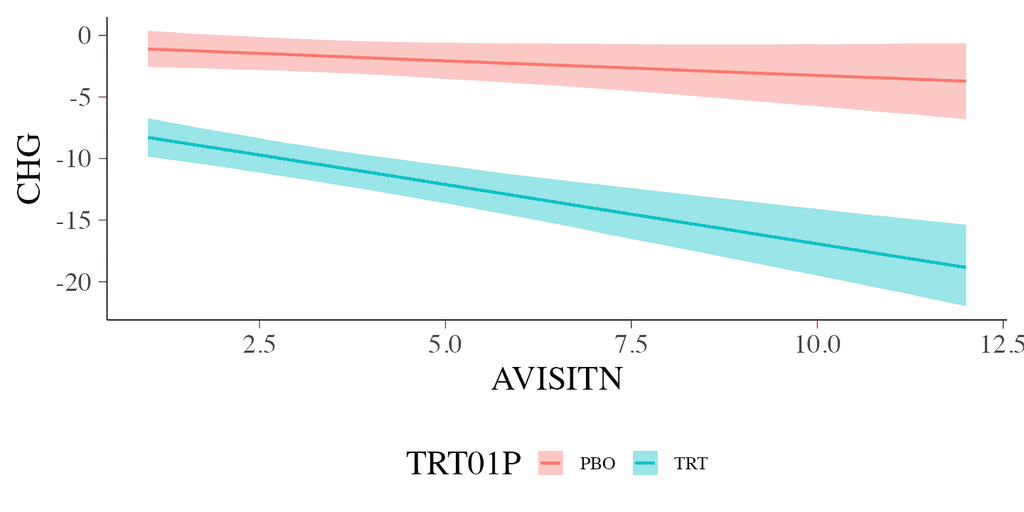

## Model Comparison

```r
loo_compare(fit_long_lin, fit_long_lin_vs)
```

```
                elpd_diff se_diff
fit_long_lin_vs    0.0       0.0
fit_long_lin    -173.9      20.5
```

## Longitudinal Data: Monotonic Model

```r
fit_long_mo <- brm(
  CHG ~ BASE + TRT01P * mo(AVISITN) +
    (1 + mo(AVISITN) | SUBJID),
  data = pasi_data, seed = 24543
)
fit_long_mo <- add_criterion(fit_long_mo, "loo")
```

Total elapsed fitting time:

```r
sum(rstan::get_elapsed_time(fit_long_mo$fit))
```

```
[1] 31.281
```

## Monotonic Model: Visualization of effects

```r
conditional_effects(fit_long_mo, "AVISITN:TRT01P")
```

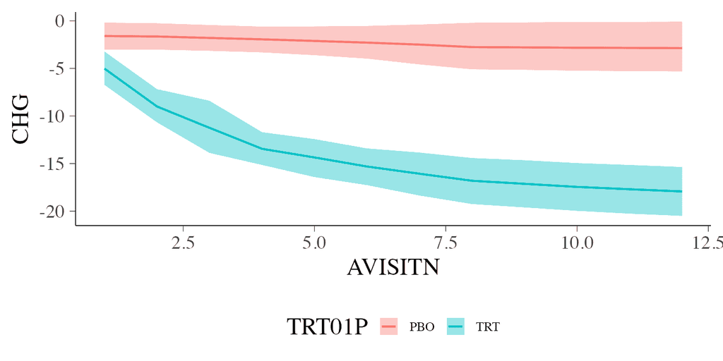